# Import Terraform configuration

Terraform supports bringing your existing infrastructure under its management. By importing resources into Terraform, you can consistently manage your infrastructure using a common workflow.

When you create new infrastructure with Terraform, you usually use the following workflow:

1. Write Terraform configuration that defines the infrastructure you want to create.
2. Review the Terraform plan to ensure the configuration will result in the expected infrastructure.
3. Apply the configuration to have Terraform create your infrastructure.

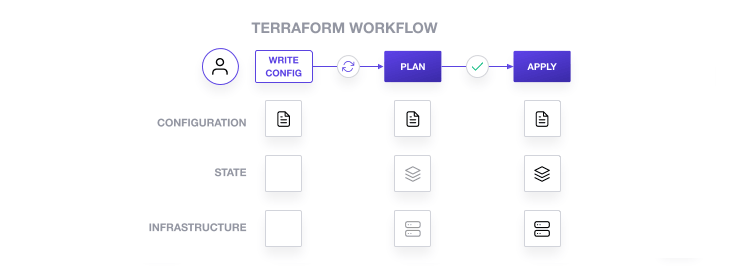

Terraform stores information about your infrastructure in a state file. To update your infrastructure, you first modify your configuration, and then use Terraform to plan and apply the required changes. Terraform uses the data in your state file to determine the changes it needs to make to your infrastructure.

As of Terraform 1.5, you can use configuration to import existing resources into your state file with the plan-and-apply workflow. You can still use the `terraform import` command, but configuration-driven import is safer, works with CICD pipelines, and allows you to preview the import operation before modifying state. You can also optionally use Terraform to generate an initial configuration for the resources you will import.

Using configuration to import resources involves the following steps:

1. Identify the existing infrastructure you will import.
2. Define an `import` block for the resources.
3. Run `terraform plan` to review the import plan and optionally generate configuration for the resources.
4. Prune generated configuration to only the required arguments.
5. Apply the configuration to bring the resource into your Terraform state file.

In this tutorial, you will create a Docker container with the Docker CLI. Then, you will declare an `import` block for the existing Docker container, use Terraform to generate configuration for the container, modify the generated configuration, and use the plan-and-apply workflow to bring the container under Terraform management.

## Prerequisites

You can complete this tutorial using the same workflow with either Terraform Community Edition or HCP Terraform.

HCP Terraform is a platform that you can use to manage and execute your Terraform projects. It includes features like remote state and execution, structured plan output, workspace resource summaries, and more.

Select the **HCP Terraform** tab to complete this tutorial using HCP Terraform.

This tutorial assumes that you are familiar with the Terraform workflow. If you are new to Terraform, complete the Get Started tutorials first.

In order to complete this tutorial, you will need the following:

- [Docker](https://docs.docker.com/get-docker/) installed and running.
- Terraform v1.5+ installed locally.

This tutorial uses HCP Terraform for remote state storage and assumes that you are familiar with the Terraform and HCP Terraform workflows. If you are new to Terraform, complete the Get Started tutorials first. If you are new to HCP Terraform, complete the HCP Terraform Get Started tutorials first.

In order to complete this tutorial, you will need the following:

- [Docker](https://docs.docker.com/get-docker/) installed and running.
- Terraform v1.5+ installed locally.
- An [HCP Terraform account](https://app.terraform.io/signup/account?utm_source=learn) with HCP Terraform locally authenticated.

### Create a Docker container

Create a container named `hashicorp-learn` using the latest NGINX image from Docker Hub, and publish that container's port 80 (HTTP) to your local host system's port 8080. You will import this container in this tutorial.

```
$ docker run --name hashicorp-learn --detach --publish "0.0.0.0:8080:80" nginx:latest
Unable to find image 'nginx:latest' locally
latest: Pulling from library/nginx
afb6ec6fdc1c: Pull complete
dd3ac8106a0b: Pull complete
8de28bdda69b: Pull complete
a2c431ac2669: Pull complete
e070d03fd1b5: Pull complete
Digest: sha256:883874c218a6c71640579ae54e6952398757ec65702f4c8ba7675655156fcca6
Status: Downloaded newer image for nginx:latest
e7ba41fd94e51c501533241e4cffd307fbda81c5b402c372d989c4578518d2e5
```

Use `docker ps` to verify that the container is running.

```
$ docker ps --filter="name=hashicorp-learn"
CONTAINER ID        IMAGE               COMMAND                  CREATED              STATUS              PORTS                  NAMES
e7ba41fd94e5        nginx:latest        "/docker-entrypoint.…"   About a minute ago   Up 59 seconds       0.0.0.0:8080->80/tcp   hashicorp-learn
```

Visit the address `localhost:8080` in your web browser to see the NGINX default index page.

Now you have a Docker image and container to import into your project and manage with Terraform.

## Initialize configuration

Now, clone the [example repository](https://github.com/hashicorp-education/learn-terraform-import) for this tutorial.

```
$ git clone https://github.com/hashicorp-education/learn-terraform-import
```

Change to the repository directory.

```
$ cd learn-terraform-import
```

Initialize this configuration.

```
$ terraform init
Initializing the backend...
##...
Terraform has been successfully initialized!
You may now begin working with Terraform. Try running "terraform plan" to see
any changes that are required for your infrastructure. All Terraform commands
should now work.
If you ever set or change modules or backend configuration for Terraform,
rerun this command to reinitialize your working directory. If you forget, other
commands will detect it and remind you to do so if necessary.
```

Open your `terraform.tf` file and uncomment the `cloud` block. Replace the `organization` name with your own HCP Terraform organization.

terraform.tf

```
terraform {
  cloud {
    organization = "organization-name"
    workspaces {
      name = "learn-terraform-import"
    }
  }

  required_providers {
    docker = {
      source  = "kreuzwerker/docker"
      version = "~> 4.2.0"
    }
  }

  required_version = "~> 1.5"
}
```

Initialize your configuration. Terraform will automatically create the `learn-terraform-import` workspace in your HCP Terraform organization.

```
$ terraform init
Initializing HCP Terraform...

Initializing provider plugins...
- Reusing previous version of kreuzwerker/docker from the dependency lock file
- Using previously-installed kreuzwerker/docker v4.2.0

HCP Terraform has been successfully initialized!

You may now begin working with HCP Terraform. Try running "terraform plan" to
see any changes that are required for your infrastructure.

If you ever set or change modules or Terraform Settings, run "terraform init"
again to reinitialize your working directory.
```

Because this tutorial uses a Docker container as the example resource to import, you must use local execution with HCP Terraform. This workflow lets you run Terraform operations locally, letting Terraform access containers and resources on your local machine. It then stores your state file in HCP Terraform for easy collaboration and versioning.

To enable local execution, navigate to your new `learn-terraform-import` workspace in HCP Terraform. In the workspace's **General settings**, select **Local** under **Execution Mode**, then click **Save settings**.

[figure not shown]

## Define import block

First, run the following command to return the full SHA256 container ID of the `hashicorp-learn` container.

```
$ docker inspect --format="{{.ID}}" hashicorp-learn
```

Now, open `docker.tf` in your editor and define an `import` block to guide the import operation. Replace `FULL_CONTAINER_ID` with the container ID from the `docker inspect` command.

docker.tf

```
import {
  id = "FULL_CONTAINER_ID"
  to = docker_container.web
}
```

Note

The identifier you use for the `id` argument in the `import` block is resource-specific. You can find the required ID in the provider documentation for the resource you wish to import. For this example, consult the [Docker provider documentation](https://registry.terraform.io/providers/kreuzwerker/docker/latest/docs/resources/container#import).

## Generate configuration

When importing a resource, you must both bring the resource into your state file, and define a corresponding `resource` block for it in your configuration. Although you can manually define the resource yourself, configuration-driven import can generate configuration for you to use as a starting point.

The generated configuration contains all possible arguments for the imported resources, including those set to default values and those without values. We recommend that you prune the generated configuration to only required arguments and arguments whose values differ from defaults, to reduce the size of your configuration.

Use `terraform plan` with the `-generate-config-out` flag to generate configuration for the container you will import. Terraform builds a plan and outputs the generated configuration for the container to the specified file.

```
$ terraform plan -generate-config-out=generated.tf

docker_container.web: Preparing import... [id=72d53edc26459adc666d60be2d57e6b8973238b6cedcc59fcb4e95639816b0bb]
docker_container.web: Refreshing state... [id=72d53edc26459adc666d60be2d57e6b8973238b6cedcc59fcb4e95639816b0bb]

Terraform used the selected providers to generate the following execution plan.
Resource actions are indicated with the following symbols:
-/+ destroy and then create replacement

Terraform will perform the following actions:

  # docker_container.web must be replaced
  # (imported from "72d53edc26459adc666d60be2d57e6b8973238b6cedcc59fcb4e95639816b0bb")
  # Warning: this will destroy the imported resource
-/+ resource "docker_container" "web" {
      ## ...
      + env               = (known after apply) # forces replacement
      ## ...
    }

Plan: 1 to import, 1 to add, 0 to change, 1 to destroy.

──────────────────────────────────────────────────────────────────────────────────────────────────────────────────────────────────────────────────────────────────────────────────────────────────────────────

Terraform has generated configuration and written it to generated.tf. Please
review the configuration and edit it as necessary before adding it to version
control.

Note: You didn't use the -out option to save this plan, so Terraform can't
guarantee to take exactly these actions if you run "terraform apply" now.
```

Terraform used the `docker` provider to find a `docker_container` resource with the ID you specified in the `import` block. It then saved the resource definition to `generated.tf`.

Notice that Terraform plans to replace the container after import due to the default value of the `env` parameter returned by the provider. You will fix this in the next section to ensure Terraform imports the container without making destructive changes to it.

Open `generated.tf` to review the generated configuration.

generated.tf

```
# __generated__ by Terraform
# Please review these resources and move them into your main configuration files.

# __generated__ by Terraform from "371e85d406a937b359d5cc3a49a423b736ec6e9367abe705dcdf6673ec1fb4c4"
resource "docker_container" "web" {
## ...
  env  = null
## ...
}
```

Notice that `env` is set to null. Open the [Docker container resource schema](https://registry.terraform.io/providers/kreuzwerker/docker/latest/docs/resources/container?ajs_aid=26421394-9a36-43bf-b4cf-d9c39318f06d&product_intent=terraform#env) for the `env` parameter. The provider expects this parameter type to be a set of strings.

Change the value of `env` to an empty set using square brackets.

generated.tf

```
resource "docker_container" "web" {
## ...
  env  = []
## ...
}
```

The container resource schema requires the `image` and `name` arguments, so you must define them in your configuration.

Recall that you specified a port mapping when you launched the Docker container, so your configuration must also contain a `ports` block that matches the current configuration of the container.

Prune the generated configuration to contain only the necessary arguments you identified.

generated.tf

```
## ...
resource "docker_container" "web" {
  env = []
  image = "..."
  name  = "hashicorp-learn"
  ports {
    external = 8080
    internal = 80
    ip       = "0.0.0.0"
    protocol = "tcp"
  }
}
```

Run `terraform plan` to verify that your configuration matches the current settings for the container.

```
$ terraform plan

docker_container.web: Preparing import... [id=72d53edc26459adc666d60be2d57e6b8973238b6cedcc59fcb4e95639816b0bb]
docker_container.web: Refreshing state... [id=72d53edc26459adc666d60be2d57e6b8973238b6cedcc59fcb4e95639816b0bb]

Terraform used the selected providers to generate the following execution plan. Resource actions are indicated with the following symbols:
  ~ update in-place

Terraform will perform the following actions:

  # docker_container.web will be updated in-place
  # (imported from "72d53edc26459adc666d60be2d57e6b8973238b6cedcc59fcb4e95639816b0bb")
  ~ resource "docker_container" "web" {
      + attach                                      = false
## ...
      + container_read_refresh_timeout_milliseconds = 15000
## ...
      + logs                                        = false
## ...
      + must_run                                    = true
## ...
      + remove_volumes                              = true
## ...
      + start                                       = true
## ...
      + wait                                        = false
      + wait_timeout                                = 60
## ...
    }

Plan: 1 to import, 0 to add, 1 to change, 0 to destroy.

──────────────────────────────────────────────────────────────────────────────────────────────────────────────────────────────────────────────────────────────────────────────────────────────────────────────

Note: You didn't use the -out option to save this plan, so Terraform can't guarantee to take exactly these actions if you run "terraform apply" now.
```

Notice that Terraform now plans to import the resource, and then make changes in place to add the `attach`, `container_read_refresh_timeout_milliseconds`, `logs`, `must_run`, `remove_volumes`, `start`, `wait`, and `wait_timeout` attributes. These are non-destructive changes.

Terraform uses these attributes to create Docker containers, but Docker does not store them. Since Docker does not track these attributes, Terraform did not include them in the generated configuration. When you apply your configuration, the Docker provider will assign the default values for these attributes and save them in state, but they will not affect the running container.

Note

Provider documentation may not indicate if a change is safe. You must understand the lifecycle of the underlying resource to know if a given change is safe to apply.

## Import and update the resource

When importing a resource, we recommend limiting any destructive changes and making the first operation on the resource a no-op. However, Terraform's configuration-driven import lets you import and modify a resource in the same operation, so you can use the Terraform workflow to manage your resource right away.

Change the `external` port to `8081`. This will be a destructive change.

generated.tf

```
## ...

resource "docker_container" "web" {
  env                                         = []
  name = "hashicorp-learn"
  image                                       = "sha256:c42efe0b54387756e68d167a437aef21451f63eebd9330bb555367d67128386c"
  ports {
    external = 8081
    internal = 80
    ip       = "0.0.0.0"
    protocol = "tcp"
  }
}
```

Now, apply the configuration. Respond `yes` to the prompt to confirm the operation.

```
$ terraform apply

docker_container.web: Preparing import...
    [id=76fc3728c7bb84137469bd3c15d3e77e57be88819e88ac6f2077da9a874cea89]
docker_container.web: Refreshing state...
    [id=76fc3728c7bb84137469bd3c15d3e77e57be88819e88ac6f2077da9a874cea89]

Terraform used the selected providers to generate the following execution plan.
Resource actions are indicated with the following symbols:
-/+ destroy and then create replacement

Terraform will perform the following actions:

  # docker_container.web must be replaced
  # (imported from "76fc3728c7bb84137469bd3c15d3e77e57be88819e88ac6f2077da9a874cea89")
  # Warning: this will destroy the imported resource
-/+ resource "docker_container" "web" {

## ...

      ~ ports {
          ~ external = 8080 -> 8081 # forces replacement
            internal = 80
            ip       = "0.0.0.0"
            protocol = "tcp"
        }
    }

Plan: 1 to import, 1 to add, 0 to change, 1 to destroy.

Do you want to perform these actions?
  Terraform will perform the actions described above.
  Only 'yes' will be accepted to approve.

  Enter a value: yes

docker_container.web: Importing... [id=76fc3728c7bb84137469bd3c15d3e77e57be88819e88ac6f2077da9a874cea89]
docker_container.web: Import complete [id=76fc3728c7bb84137469bd3c15d3e77e57be88819e88ac6f2077da9a874cea89]
docker_container.web: Destroying... [id=76fc3728c7bb84137469bd3c15d3e77e57be88819e88ac6f2077da9a874cea89]
docker_container.web: Destruction complete after 0s
docker_container.web: Creating...
docker_container.web: Creation complete after 0s [id=c30d6bc712cd95e41260a04f1a979ae9c91a054a8ba32f2bbabb09f0e7f95220]

Apply complete! Resources: 1 imported, 1 added, 0 changed, 1 destroyed.
```

Terraform imported the resource, then replaced the container since you changed the external port mapping.

Now verify that Terraform replaced the container with a new one by running `docker ps` or visiting `localhost:8081` in your web browser.

```
$ docker ps --filter "name=hashicorp-learn"
CONTAINER ID   IMAGE          COMMAND                  CREATED          STATUS          PORTS                  NAMES
c30d6bc712cd   c42efe0b5438   "/docker-entrypoint.…"   50 seconds ago   Up 50 seconds   0.0.0.0:8081->80/tcp   hashicorp-learn
```

Review the contents of your state file by running `terraform show`.

```
$ terraform show
# docker_container.web:
resource "docker_container" "web" {
    attach                                      = false
    command           = [
      "nginx",
      "-g",
      "daemon off;",
    ]

    ## ...

    ports {
      external = 8081
      internal = 80
      ip       = "0.0.0.0"
      protocol = "tcp"
    }
}
```

Now your configuration file, Terraform state, and the container are all in sync, and you can use Terraform to manage the Docker container's settings and lifecycle.

## Create image resource

You can bring some resources under Terraform's management without using the `import` block. This is often the case for resources defined by a single unique ID or tag, such as Docker images.

In your `generated.tf` file, the `docker_container.web` resource specifies the SHA256 hash ID of the image used to create the container. This is how Docker stores the image ID internally, so the import operation loaded the image ID directly into your state. However, identifying the image by its tag or name would make your configuration easier to understand.

Retrieve the image's tag name by running the following command.

```
$ docker image inspect -f {{.RepoTags}} `docker inspect --format="{{.Image}}" hashicorp-learn`
[nginx:latest]
```

Then add the following configuration to your `docker.tf` file to represent this image as a resource.

docker.tf

```
resource "docker_image" "nginx" {
  name         = "nginx:latest"
}
```

Warning

Do not replace the `image` value in the `docker_container.web` resource yet, or Terraform will destroy and recreate your container. Since Terraform did not yet load the `docker_image.nginx` resource into state, it does not have an image ID to compare with the hardcoded one, which will force replacement. The image resource must exist in state before you can reference it.

Run `terraform apply` to create an image resource in state. Remember to confirm the apply step with a `yes`.

```
$ terraform apply
docker_container.web: Refreshing state... [id=5cf0052f45a4c22e6b077ca476cd0f584f4e874b64c1a7c89e8a3ceb2e41bad6]

Terraform used the selected providers to generate the following execution plan. Resource actions are indicated with the following symbols:
  + create

Terraform will perform the following actions:

  # docker_image.nginx will be created
  + resource "docker_image" "nginx" {
      + id          = (known after apply)
      + image_id    = (known after apply)
      + name        = "nginx:latest"
      + repo_digest = (known after apply)
    }

Plan: 1 to add, 0 to change, 0 to destroy.

##...

Apply complete! Resources: 1 added, 0 changed, 0 destroyed
```

Now that Terraform created a resource for the image, you can reference it in your container's configuration. Change the `image` value for `docker_container.web` to reference the new image resource.

generated.tf

```
resource "docker_container" "web" {
  ## ...
  image = docker_image.nginx.image_id
  ## ...
}
```

```
$ terraform apply
docker_image.nginx: Refreshing state... [id=sha256:9e7e7b26c784556498f584508123ae46da82b4915e262975893be4c8ec8009a5nginx:latest]
docker_container.web: Refreshing state... [id=5cf0052f45a4c22e6b077ca476cd0f584f4e874b64c1a7c89e8a3ceb2e41bad6]

No changes. Your infrastructure matches the configuration.

Terraform has compared your real infrastructure against your configuration and found no differences, so no changes are needed.
```

Note

If the image ID for the tag `nginx:latest` changes between the time you first create the Docker container and when you update the configuration to reference the new image, Terraform will destroy the container and then recreate it with the new image.

Now that Terraform manages both the Docker container and image, you can use Terraform to modify their configuration.

## Destroy infrastructure

You have now imported your Docker container and its image used into Terraform.

Destroy the container and image by running `terraform destroy`. Respond `yes` to the prompt to confirm the operation.

```
$ terraform destroy
docker_image.nginx: Refreshing state... [id=sha256:9beeba249f3ee158d3e495a6ac25c5667ae2de8a43ac2a8bfd2bf687a58c06c9nginx:latest]
docker_container.web: Refreshing state... [id=3fe1cb2e5326c31bac9250f6d09eade77945ee07ccea025d6424d91a89f98557]

An execution plan has been generated and is shown below.
Resource actions are indicated with the following symbols:
  - destroy

Terraform will perform the following actions:

  # docker_container.web will be destroyed
  - resource "docker_container" "web" {
      - attach            = false -> null

      ## ...
    }

Plan: 0 to add, 0 to change, 2 to destroy.

Do you really want to destroy all resources?
  Terraform will destroy all your managed infrastructure, as shown above.
  There is no undo. Only 'yes' will be accepted to confirm.

  Enter a value: yes

docker_container.web: Destroying... [id=3fe1cb2e5326c31bac9250f6d09eade77945ee07ccea025d6424d91a89f98557]
docker_container.web: Destruction complete after 1s
docker_image.nginx: Destroying... [id=sha256:9beeba249f3ee158d3e495a6ac25c5667ae2de8a43ac2a8bfd2bf687a58c06c9nginx:latest]
docker_image.nginx: Destruction complete after 0s

Destroy complete! Resources: 2 destroyed.
```

Finally, run `docker ps` to validate that Terraform destroyed the container.

```
$ docker ps --filter "name=hashicorp-learn"
CONTAINER ID        IMAGE               COMMAND             CREATED             STATUS              PORTS               NAMES
```

If you used HCP Terraform for this tutorial, after destroying your resources, delete the `learn-terraform-import` workspace from your HCP Terraform organization.

Tip

Since you added both the image and the container to your Terraform configuration, Terraform will remove both from Docker. If another container uses the same image, the destroy step will fail. Remember that importing a resource into Terraform means that Terraform will manage the entire lifecycle of the resource, including destruction.

## Limitations and other considerations

There are several important things to consider when using configuration to import resources into Terraform:

- Terraform import uses the current state of your infrastructure reported by the provider. It cannot determine:
  - the health of the infrastructure.
  - the intent of the infrastructure.
  - changes made to the infrastructure that are not in Terraform's control, such as the state of a Docker container's filesystem.
- Importing involves manual steps which can be error prone, especially if the operator lacks context about the purpose and history of the infrastructure. We recommend carefully reviewing plan output before applying to avoid destructive changes.
- Importing manipulates the Terraform state file during the apply. You may want to create a backup before importing new infrastructure.
- Terraform import does not detect or generate relationships between infrastructure. You can manually add relationships to the configuration before you apply changes.
- Terraform import does not detect which default attributes you can skip setting.
- Not all providers and resources support Terraform import.
- Importing a resource into Terraform does not mean that Terraform can destroy and recreate it. For example, the imported infrastructure could rely on other unmanaged infrastructure or configuration.

Following Infrastructure as Code (IaC) best practices, such as [immutable infrastructure](https://www.hashicorp.com/resources/what-is-mutable-vs-immutable-infrastructure/), can help prevent many of these problems.

## Next steps

In this tutorial, you used configuration-driven import to bring a Docker container under Terraform management. You then used Terraform to modify its configuration, including defining resource dependencies. You also reviewed the limitations of the import workflow, and the enhanced safety and predictability configuration-driven import offers over the `terraform import` command.

Review the following resources to learn more about how to use Terraform to safely and consistently manage your infrastructure:

- Review the Terraform Import documentation.
- Learn how to migrate configuration to HCP Terraform.
- Learn how to create reusable configuration with modules.
- Learn how to manage a resource in Terraform state.